# Project Python Foundations: FoodHub Data Analysis

**Marks: 60**

### Context

The number of restaurants in New York is increasing day by day. Lots of students and busy professionals rely on those restaurants due to their hectic lifestyles. Online food delivery service is a great option for them. It provides them with good food from their favorite restaurants. A food aggregator company FoodHub offers access to multiple restaurants through a single smartphone app.

The app allows the restaurants to receive a direct online order from a customer. The app assigns a delivery person from the company to pick up the order after it is confirmed by the restaurant. The delivery person then uses the map to reach the restaurant and waits for the food package. Once the food package is handed over to the delivery person, he/she confirms the pick-up in the app and travels to the customer's location to deliver the food. The delivery person confirms the drop-off in the app after delivering the food package to the customer. The customer can rate the order in the app. The food aggregator earns money by collecting a fixed margin of the delivery order from the restaurants.

### Objective

The food aggregator company has stored the data of the different orders made by the registered customers in their online portal. They want to analyze the data to get a fair idea about the demand of different restaurants which will help them in enhancing their customer experience. Suppose you are hired as a Data Scientist in this company and the Data Science team has shared some of the key questions that need to be answered. Perform the data analysis to find answers to these questions that will help the company to improve the business.

### Data Description

The data contains the different data related to a food order. The detailed data dictionary is given below.

### Data Dictionary

- order_id: Unique ID of the order
- customer_id: ID of the customer who ordered the food
- restaurant_name: Name of the restaurant
- cuisine_type: Cuisine ordered by the customer
- cost: Cost of the order
- day_of_the_week: Indicates whether the order is placed on a weekday or weekend (The weekday is from Monday to Friday and the weekend is Saturday and Sunday)
- rating: Rating given by the customer out of 5
- food_preparation_time: Time (in minutes) taken by the restaurant to prepare the food. This is calculated by taking the difference between the timestamps of the restaurant's order confirmation and the delivery person's pick-up confirmation.
- delivery_time: Time (in minutes) taken by the delivery person to deliver the food package. This is calculated by taking the difference between the timestamps of the delivery person's pick-up confirmation and drop-off information

### Let us start by importing the required libraries

```python
# import libraries for data manipulation
import numpy as np
import pandas as pd

# import libraries for data visualization
import matplotlib.pyplot as plt
import seaborn as sns

pd.set_option('display.float_format', lambda x: '%.2f' % x)
```

### Understanding the structure of the data

```python
# read the data
df = pd.read_csv('foodhub_order.csv')
# returns the first 5 rows
df.head()
```

|  | order_id | customer_id | restaurant_name | cuisine_type | cost_of_the_order | day_of_the_week | rating | food_preparation_time | delivery_time |
| --- | --- | --- | --- | --- | --- | --- | --- | --- | --- |
| 0 | 1477147 | 337525 | Hangawi | Korean | 30.75 | Weekend | Not given | 25 | 20 |
| 1 | 1477685 | 358141 | Blue Ribbon Sushi Izakaya | Japanese | 12.08 | Weekend | Not given | 25 | 23 |
| 2 | 1477070 | 66393 | Cafe Habana | Mexican | 12.23 | Weekday | 5 | 23 | 28 |
| 3 | 1477334 | 106968 | Blue Ribbon Fried Chicken | American | 29.20 | Weekend | 3 | 25 | 15 |
| 4 | 1478249 | 76942 | Dirty Bird to Go | American | 11.59 | Weekday | 4 | 25 | 24 |

#### Observations:

The DataFrame has 9 columns as mentioned in the Data Dictionary. Data in each row corresponds to the order placed by a customer.

### **Question 1:** How many rows and columns are present in the data? [0.5 mark]

```python
print(f"Number of rows: {df.shape[0] }, Number of columns {df.shape[1]}")
```

```
Number of rows: 1898, Number of columns 9
```

#### Observations:

### **Question 2:** What are the datatypes of the different columns in the dataset? (The info() function can be used) [0.5 mark]

```python
# Use info() to print a concise summary of the DataFrame
df.info()
```

```
<class 'pandas.core.frame.DataFrame'>
RangeIndex: 1898 entries, 0 to 1897
Data columns (total 9 columns):
 #   Column                 Non-Null Count  Dtype
---  ------                 --------------  -----
 0   order_id               1898 non-null   int64
 1   customer_id            1898 non-null   int64
 2   restaurant_name        1898 non-null   object
 3   cuisine_type           1898 non-null   object
 4   cost_of_the_order      1898 non-null   float64
 5   day_of_the_week        1898 non-null   object
 6   rating                 1898 non-null   object
 7   food_preparation_time  1898 non-null   int64
 8   delivery_time          1898 non-null   int64
dtypes: float64(1), int64(4), object(4)
memory usage: 133.6+ KB
```

#### Observations:

There are 1898 rows and 9 columns in the DataFrame. The data types of the columns are:

- order_id: int64
- customer_id: int64
- restaurant_name: object
- cuisine_type: object
- cost_of_the_order: float64
- day_of_the_week: object
- rating: object
- food_preparation_time: int64
- delivery_time: int64

The memory usage of the DataFrame is 133.6+ KB.

### **Question 3:** Are there any missing values in the data? If yes, treat them using an appropriate method. [1 mark]

```python
# Write your code here
print(df.isnull().sum())
```

[output not shown]

#### Observations:

There are not missing values in the data frame

### **Question 4:** Check the statistical summary of the data. What is the minimum, average, and maximum time it takes for food to be prepared once an order is placed? [2 marks]

```python
# Write your code here
# The Python code df.describe().T is used to transpose the output of the describe() method.
# The describe() method returns a DataFrame that contains descriptive statistics for each column of the DataFrame.
df.describe(include='all').T
```

|  | count | unique | top | freq | mean | std | min | 25% | 50% | 75% | max |
| --- | --- | --- | --- | --- | --- | --- | --- | --- | --- | --- | --- |
| order_id | 1898.00 | NaN | NaN | NaN | 1477495.50 | 548.05 | 1476547.00 | 1477021.25 | 1477495.50 | 1477969.75 | 1478444.00 |
| customer_id | 1898.00 | NaN | NaN | NaN | 171168.48 | 113698.14 | 1311.00 | 77787.75 | 128600.00 | 270525.00 | 405334.00 |
| restaurant_name | 1898 | 178 | Shake Shack | 219 | NaN | NaN | NaN | NaN | NaN | NaN | NaN |
| cuisine_type | 1898 | 14 | American | 584 | NaN | NaN | NaN | NaN | NaN | NaN | NaN |
| cost_of_the_order | 1898.00 | NaN | NaN | NaN | 16.50 | 7.48 | 4.47 | 12.08 | 14.14 | 22.30 | 35.41 |
| day_of_the_week | 1898 | 2 | Weekend | 1351 | NaN | NaN | NaN | NaN | NaN | NaN | NaN |
| rating | 1898 | 4 | Not given | 736 | NaN | NaN | NaN | NaN | NaN | NaN | NaN |
| food_preparation_time | 1898.00 | NaN | NaN | NaN | 27.37 | 4.63 | 20.00 | 23.00 | 27.00 | 31.00 | 35.00 |
| delivery_time | 1898.00 | NaN | NaN | NaN | 24.16 | 4.97 | 15.00 | 20.00 | 25.00 | 28.00 | 33.00 |

#### Observations:

Food preparation time

- min:20.00
- max:35.00
- average:27.37

### **Question 5:** How many orders are not rated? [1 mark]

```python
# Write the code here
# The unique() method returns a NumPy array of the unique values in the column.
print(f"Unique rating values: {df['rating'].unique()}")

# The code df['rating'].value_counts() is used to get the counts of the unique values in the rating column of the DataFrame df.
print(f"Number of non-rated orders: {df['rating'].value_counts()['Not given']}")
```

```
Unique rating values: ['Not given' '5' '3' '4']
Number of non-rated orders: 736
```

### Exploratory Data Analysis (EDA)

### **Question 6:** Explore all the variables and provide observations on their distributions. (Generally, histograms, boxplots, countplots, etc. are used for univariate exploration.) [9 marks]

```python
df.describe(include='all').T
```

|  | count | unique | top | freq | mean | std | min | 25% | 50% | 75% | max |
| --- | --- | --- | --- | --- | --- | --- | --- | --- | --- | --- | --- |
| order_id | 1898.00 | NaN | NaN | NaN | 1477495.50 | 548.05 | 1476547.00 | 1477021.25 | 1477495.50 | 1477969.75 | 1478444.00 |
| customer_id | 1898.00 | NaN | NaN | NaN | 171168.48 | 113698.14 | 1311.00 | 77787.75 | 128600.00 | 270525.00 | 405334.00 |
| restaurant_name | 1898 | 178 | Shake Shack | 219 | NaN | NaN | NaN | NaN | NaN | NaN | NaN |
| cuisine_type | 1898 | 14 | American | 584 | NaN | NaN | NaN | NaN | NaN | NaN | NaN |
| cost_of_the_order | 1898.00 | NaN | NaN | NaN | 16.50 | 7.48 | 4.47 | 12.08 | 14.14 | 22.30 | 35.41 |
| day_of_the_week | 1898 | 2 | Weekend | 1351 | NaN | NaN | NaN | NaN | NaN | NaN | NaN |
| rating | 1898 | 4 | Not given | 736 | NaN | NaN | NaN | NaN | NaN | NaN | NaN |
| food_preparation_time | 1898.00 | NaN | NaN | NaN | 27.37 | 4.63 | 20.00 | 23.00 | 27.00 | 31.00 | 35.00 |
| delivery_time | 1898.00 | NaN | NaN | NaN | 24.16 | 4.97 | 15.00 | 20.00 | 25.00 | 28.00 | 33.00 |

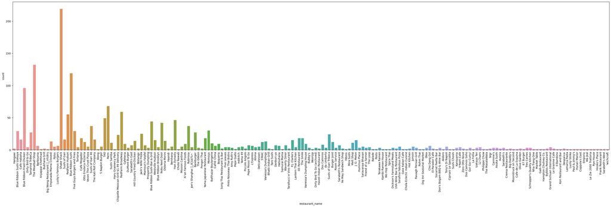

```python
plt.figure(figsize=(40,10));
sns.countplot(data=df,x='restaurant_name');
plt.xticks(rotation=90);
```

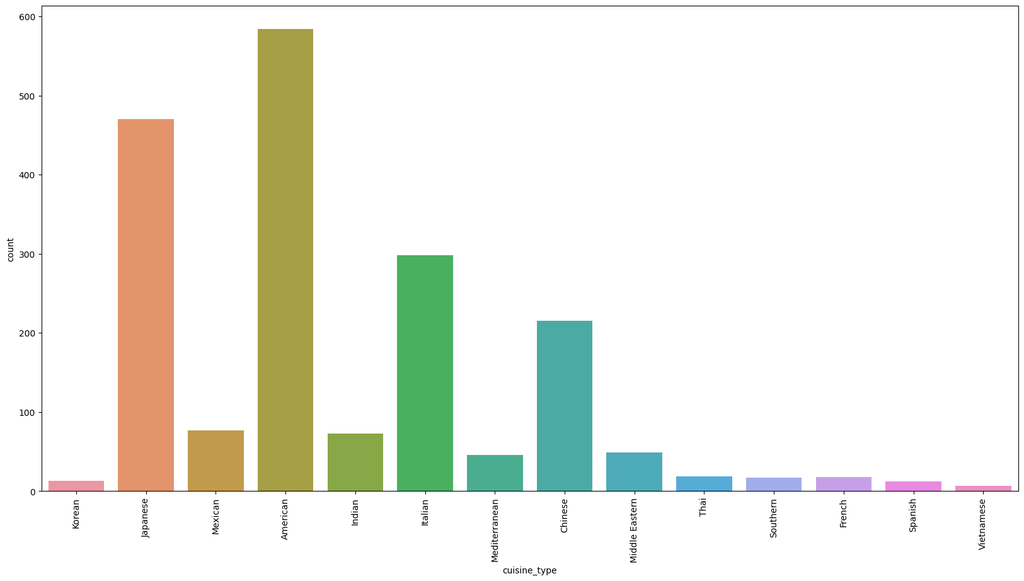

```python
plt.figure(figsize=(20,10));
sns.countplot(data=df,x='cuisine_type');
plt.xticks(rotation=90);
```

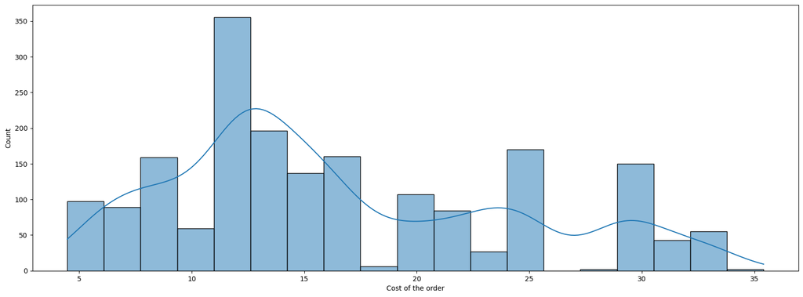

```python
plt.figure(figsize=(20,7));
sns.histplot(data=df,x='cost_of_the_order',kde=True);
plt.xlabel('Cost of the order')
plt.show()
```

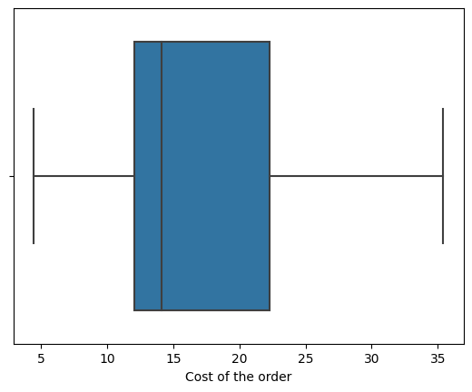

```python
sns.boxplot(data=df,x='cost_of_the_order');
plt.xlabel('Cost of the order');
```

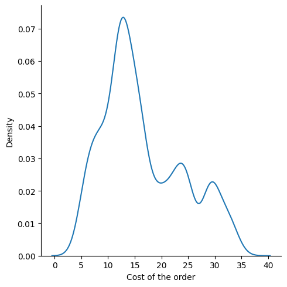

```python
sns.displot(data=df,x='cost_of_the_order',kind='kde');
plt.xlabel('Cost of the order');
```

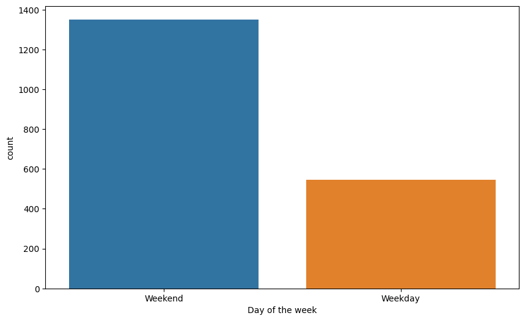

```python
plt.figure(figsize=(10,6));
sns.countplot(data=df,x='day_of_the_week');
plt.xlabel('Day of the week');
```

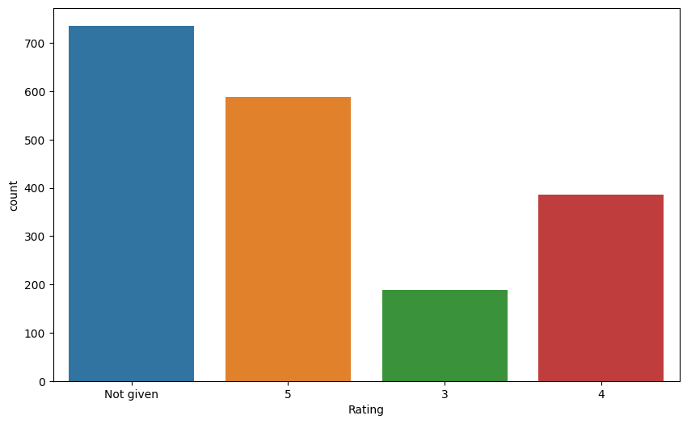

```python
df['rating'].unique()
plt.figure(figsize=(10,6));
sns.countplot(data=df,x='rating');
plt.xlabel('Rating');
```

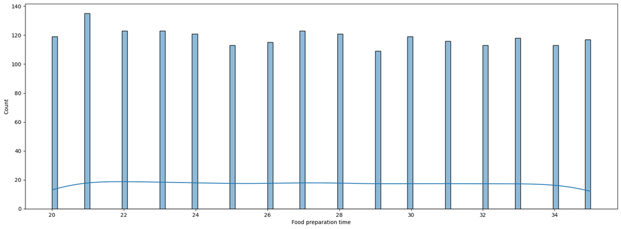

```python
plt.figure(figsize=(20,7));
sns.histplot(data=df,x='food_preparation_time',kde=True,bins=100);
plt.xlabel('Food preparation time')
plt.show()
```

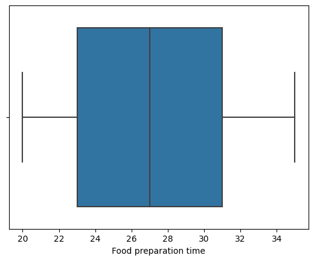

```python
sns.boxplot(data=df,x='food_preparation_time');
plt.xlabel('Food preparation time');
```

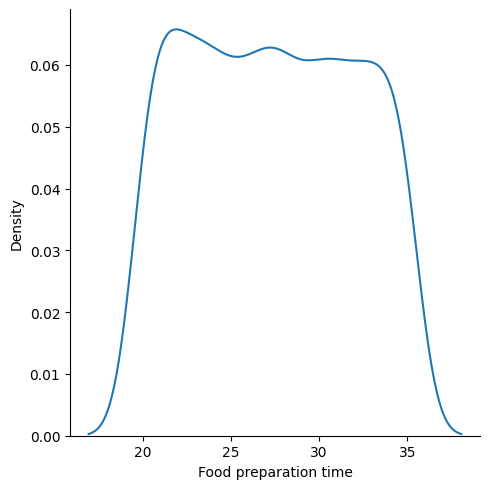

```python
sns.displot(data=df,x='food_preparation_time',kind='kde');
plt.xlabel('Food preparation time');
```

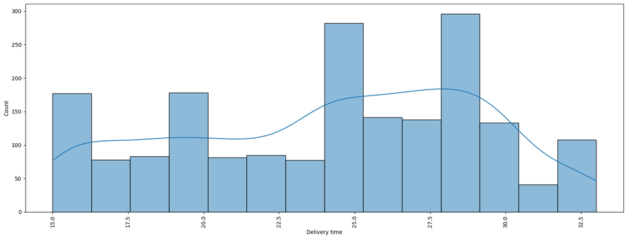

```python
plt.figure(figsize=(20,7));
sns.histplot(data=df,x='delivery_time',kde=True);
plt.xticks(rotation=90);
plt.xlabel('Delivery time')
plt.show()
```

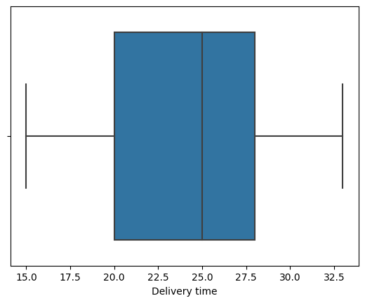

```python
sns.boxplot(data=df,x='delivery_time');
plt.xlabel('Delivery time');
```

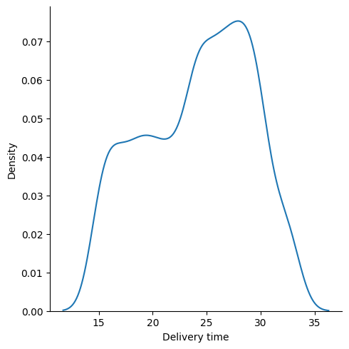

```python
sns.displot(data=df,x='delivery_time',kind='kde');
plt.xlabel('Delivery time');
```

#### Observations:

##### restaurant_name

- Has 178 unique values, with the most common restaurant being Shake Shack (219 orders).
- Has a right-skewed distribution. This means that the majority of the values are concentrated on the left side of the distribution, with a few extreme values on the right side.

##### cuisine_type

- The cuisine_type column has 14 unique values, with the most common cuisine being American (584 orders).

##### day_of_the_week

- The day_of_the_week column has 2 unique values, with Weekend being the most common day (1351 orders).

##### rating

- The rating column has 4 unique values, with Not given being the most common rating (736 orders).

### **Question 7**: Which are the top 5 restaurants in terms of the number of orders received? [1 mark]

```python
# Write the code here
# value_counts() is used to count the number of times each unique value appears in the restaurant_name column of the DataFrame
df['restaurant_name'].value_counts().head(5)
```

```
restaurant_name
Shake Shack                  219
The Meatball Shop            132
Blue Ribbon Sushi            119
Blue Ribbon Fried Chicken     96
Parm                          68
Name: count, dtype: int64
```

### **Question 8**: Which is the most popular cuisine on weekends? [1 mark]

```python
# Write the code here
# This code is used to count the number of times each unique value appears in the
# cuisine_type column of the DataFrame for rows where the day_of_the_week column is equal
# to "Weekend".
df[df['day_of_the_week']=='Weekend']['cuisine_type'].value_counts()
```

```
cuisine_type
American          415
Japanese          335
Italian           207
Chinese           163
Mexican            53
Indian             49
Mediterranean      32
Middle Eastern     32
Thai               15
French             13
Korean             11
Southern           11
Spanish            11
Vietnamese          4
Name: count, dtype: int64
```

#### Observations:

The most popular cuisine on weekends is: American

### **Question 9**: What percentage of the orders cost more than 20 dollars? [2 marks]

```python
# Write the code here
# This code is used to calculate the percentage of orders that cost more than $20.
# The code first creates a new DataFrame df that contains only the rows where the
# cost_of_the_order column is greater than $20.
# The count() method is then used to count the number of rows in this new DataFrame.
# The shape method is then used to get the total number of rows in the original DataFrame.
# The *100 operator is then used to multiply the count by 100 to get the percentage.
percentage=df[df['cost_of_the_order']>20]['cost_of_the_order'].count()/df.shape[0]*100
print(f"The percentage of the orders that cost more than 20 dollars is: {round(percentage,2)}%")
```

```
The percentage of the orders that cost more than 20 dollars is: 29.24%
```

### **Question 10**: What is the mean order delivery time? [1 mark]

```python
# Write the code here
# This code is used to calculate the mean delivery time for all orders in the DataFrame
delivery_time_mean=df['delivery_time'].mean()
print(f"The mean order delivery time is: {round(delivery_time_mean,2)}")
```

```
The mean order delivery time is: 24.16
```

### **Question 11:** The company has decided to give 20% discount vouchers to the top 3 most frequent customers. Find the IDs of these customers and the number of orders they placed. [1 mark]

```python
# Write the code here
df['customer_id'].value_counts().head(3)
```

```
customer_id
52832    13
47440    10
83287     9
Name: count, dtype: int64
```

#### Observations:

The top 3 most frequent customers are:

| Customer ID | Number of Orders |
| --- | --- |
| 52832 | 13 |
| 47440 | 10 |
| 83287 | 9 |

### **Question 12**: Perform a multivariate analysis to explore relationships between the important variables in the dataset. (It is a good idea to explore relations between numerical variables as well as relations between numerical and categorical variables) [10 marks]

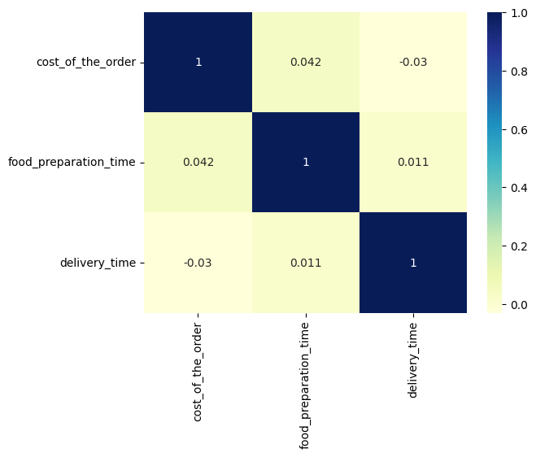

```python
# Write the code here
# this code  is used to create a heatmap of the correlation between the cost_of_the_order,
# food_preparation_time, and delivery_time columns in the DataFrame df.
# The corr() method calculates the correlation between the columns, and the heatmap() method
# plots the correlation as a heatmap. The annot=True argument adds the correlation coefficients
# to the heatmap, and the cmap='YlGnBu' argument sets the colormap to a blue-green colormap.
sns.heatmap(data=df[['cost_of_the_order','food_preparation_time','delivery_time']].corr(),annot=True,cmap='YlGnBu');
```

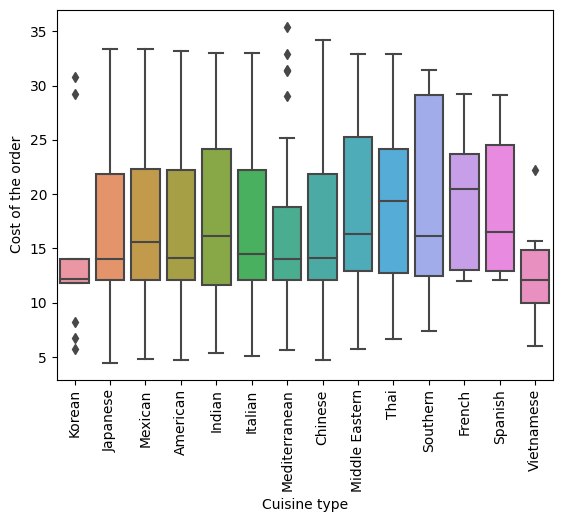

```python
# This code is used to create the boxplot. The data parameter specifies the data frame that
# contains the data, the x parameter specifies the column that contains the cuisine type,
# and the y parameter specifies the column that contains the cost of the order.
sns.boxplot(data=df, x='cuisine_type', y='cost_of_the_order');
plt.xlabel('Cuisine type')
plt.ylabel('Cost of the order')
plt.xticks(rotation=90);
```

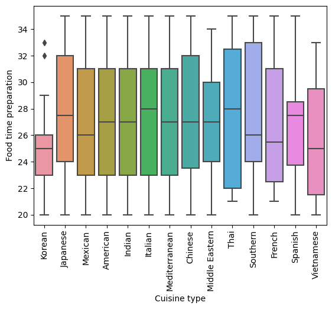

```python
# This code is used to create the boxplot. The data parameter specifies the data frame that
# contains the data, the x parameter specifies the column that contains the cuisine type,
# and the y parameter specifies the column that contains the food preparation time.
sns.boxplot(data=df, x='cuisine_type', y='food_preparation_time');
plt.xlabel('Cuisine type')
plt.ylabel('Food time preparation')
plt.xticks(rotation=90);
```